# Introduction to Google Earth Engine for Ecologists and Practitioners

Ramiro D Crego, Grant Connette, Jared Stabach

25 August 2025

[figure not shown]

[figure not shown]

## 1 Preface

Google Earth Engine is a cloud-based platform hosted by Google that uses Google’s high-performance and intrinsically parallel computing system that subdivides computations across the Google computational infrastructure, accelerating computational processes (Gorelick et al., 2017). It has been primarily designed to process and analyze satellite imagery and geospatial datasets, making computationally demanding workflows more accessible for research, education and other nonprofit use at no user cost. Thus, it is totally free.

Up to 2008, using satellite imagery for data analysis was expensive. In 2008, however, the United States Geological Survey (USGS) opted for a free and open policy on the use of the most popular satellite, Landsat (Woodcock et al., 2008). The release of Landsat catalog to be freely use by the public opened enormously the possibilities to expand earth research (Woulder et al., 2019). However, with so much data available, the limitation became data processing rather than data gathering. Personal computers are generally limited in computation power to analyze the amount of data that a composite of Landsat images require and data storage is also limited. Supercomputers can do that job, but access them is only optional for researchers working in certain institutions. Google opened the option for all users with internet access to operate on a high computing infrastructure through the new platform, Google Earth Engine.

When the increase of satellite data accessibility is combined with free access to fast computing processes, researchers and students have the possibility to carry out extremely high computing demanding projects in matter of minutes. For ecologists, this has opened the horizons of research possibilities in unthinkable ways. And while lot of attention has been put into the use of Google Earth Engine for remote sensing scientists (Tamimina et al., 2020), the tool has not reached yet the spatial ecological field in its full capacity. In this tutorial, we explore the different applications that this platform provides to analyze data for projects focused on spatial ecology.

### 1.1 Goals

This workshop is intended to provide an introduction to GEE for participants in the fields of ecology, conservation, and wildlife biology. The course will begin by covering the basics of GEE and JavaScript coding before moving on to spatial data manipulation and analyses. Participants need no prior experience working with GEE, but should have a basic understanding of GIS data and concepts, such as raster (including stacks or multi-band images), vectors, projections, and spatial resolution. This course is a continuation of a previous year’s module “Introduction to Geographic Information Systems (GIS) and Wildlife Population Monitoring in R.” At the conclusion of the course, we will combine GEE workflows with population analysis in R, with a goal of creating a community of practitioners that have the skills necessary to expand upon science-based monitoring of wildlife populations across Kenya.

### 1.2 Learning Outcomes

You are expected to use your own computer for all exercises. By the end of this course, you will be able to:

- Understand GEE’s web interface
- Access and manipulate spatial data from the GEE catalog
- Understand the fundamentals of JavaScript code
- Perform basic spatial data processing (i.e., standard GIS operations)
- Gain experience with species distribution modeling (i.e., random forest, MaxEnt)
- Download GEE data to incorporate in R workflows to assess species abundance
- Use R to create maps and visualize data
- Make maps that show predictions based on statistical models

### 1.3 How to use this material

Here we present a tutorial that will guide you on the use of different model techniques for data analysis. The main goal is that after the workshop, you will be able to continue practicing with this tutorial, and master your skills to analyze your data using Google Earth Engine interface.

The tutorial is organized in 5 main sections. Section 1 is an introduction to Google Earth Engine and the JavaScript language we use to code. Section 2 will guide you on the use of images and geometries, or raster and vector data. Section 3 is an opportunity to lonk GEE with other interfaces like R to make visualizations of your data. Section 4 is an introduction to the implementation of Species Distribution Models with GEE. Section 5 will bring us back to Distance Sampling and the use of covariables extracted with GEE in the modeling process.

> All that code is available [here](https://code.earthengine.google.com/?accept_repo=users/jaredstabach/NASA_EcoCons_Mara).

### 1.4 Instructors

- Jared Stabach, PhD., Ecologist, Conservation Ecology Center, Smithsonian’s National Zoo and Conservation Biology Institute, Front Royal, VA, USA. Email: stabachj@si.edu
- Grant Connette, Ph.D., Ecologist, Conservation Ecology Center, Smithsonian’s National Zoo and Conservation Biology Institute, Front Royal, VA, USA. Email: connetteg@si.edu
- Ramiro D Crego, Ph.D., Lecturer in Zoology/Animal Ecology, School of Biological, Earth & Environmental Sciences - Environmental Research Institute, University College Cork, Ireland. Email: rcrego@ucc.ie

### 1.5 References

Gorelick, N., Hancher, M., Dixon, M., Ilyushchenko, S., Thau, D., & Moore, R. (2017). Google Earth Engine: Planetary-scale geospatial analysis for everyone. Remote Sensing of Environment, 202, 18–27. https://doi.org/10.1016/j.rse.2017.06.031

C.E. Woodcock, R. Allen, M. Anderson, A. Belward, R. Bindschadler, W. Cohen, F. Gao, S.N. Goward, D. Helder, E. Helmer, R. Nemani, L. Oreopoulos, J. Schott, P.S. Thenkabail, E.F. Vermote, J. Vogelmann, M.A. Wulder, R. Wynne. 2008. Free access to Landsat imagery. Science, 302 (5879), p. 1011

Michael A. Wulder, Thomas R. Loveland, David P. Roy, Christopher J. Crawford, Jeffrey G. Masek, Curtis E. Woodcock, Richard G. Allen, Martha C. Anderson, Alan S. Belward, Warren B. Cohen, John Dwyer, Angela Erb, Feng Gao, Patrick Griffiths, Dennis Helder, Txomin Hermosilla, James D. Hipple, Patrick Hostert, M. Joseph Hughes, Justin Huntington, David M. Johnson, Robert Kennedy, Ayse Kilic, Zhan Li, Leo Lymburner, Joel McCorkel, Nima Pahlevan, Theodore A. Scambos, Crystal Schaaf, John R. Schott, Yongwei Sheng, James Storey, Eric Vermote, James Vogelmann, Joanne C. White, Randolph H. Wynne, Zhe Zhu. 2019. Current status of Landsat program, science, and applications, Remote Sensing of Environment, 225, 127-147, https://doi.org/10.1016/j.rse.2019.02.015.

Haifa Tamiminia, Bahram Salehi, Masoud Mahdianpari, Lindi Quackenbush, Sarina Adeli, Brian Brisco. 2020. Google Earth Engine for geo-big data applications: A meta-analysis and systematic review. ISPRS Journal of Photogrammetry and Remote Sensing, 164, 152-170, https://doi.org/10.1016/j.isprsjprs.2020.04.001.

## 2 A brief introduction to Google Earth Engine

Google Earth Engine (GEE) is an online Integrated Development Environment (IDE) for rapid development and visualization of complex spatial analyses using the JavaScript or Phyton coding languages, allowing users to conduct data heavy analysis. While computer coding can sound challenging for ecologists, researchers, students or managers that have never used code before, it is rather simple and opens the spectrum of data analysis enormously. The integrated platform that Google Earth Engine provides allows not only traditional remote sensing scientists, but also a much broader spectrum of users to run spatial analysis, without the need to have deep expertise on the use of supercomputers.

The GEE platform has the main advantage of providing access to:

1. Petabytes of remote sensing imagery and other spatial products;
2. High-speed parallel processing and machine learning algorithms;
3. A library of Application Programming Interfaces (APIs) with development environments

These three features enable the user to visualize and analyze a bast range of geospatial data fast and for free, without the need to access a supercomputers (Gorelick et al., 2017).

Google Earth Engine Application Programming Interface (API) can be run in popular coding languages, such as JavaScript and Phyton. In this tutorial we will focus on the use of JavaScript. In this first section we will explore the basics of Google Earth Engine, from understanding how to set up an account, to understand the interface to explaining the basics of JavaScript coding language.

### 2.1 Setting up a Google Earth Engine account:

The first step to start using Google Earth Engine is to set up a Google Cloud project. In this [link](https://console.cloud.google.com/earth-engine/welcome?inv=1&invt=Ab42LQ) you will find the instructions. If you are working in research or for non-profit organizations, you can register a free or charge non-commercial project.

### 2.2 The Google Earth Engine Interface

Once your Google Earth Engine account is set, you will be able to aces the Code Editor to start working on it in your browser at https://code.earthengine.google.com/.

The Google Earth Engine interface is an interactive web-based environment for data analysis. It has four main panels (Fig. 1):

1. The `Code Editor panel` to write JavaScript code.
2. The `Left panel` for managing and hosting programming scripts, accessing Google Earth Engine documents and managing and uploading external data sets such as shapefiles.
3. The `Right panel` with tabs for printing, queering maps and exporting products or long-running tasks.
4. The `Interactive map panel` for visualizing maps and outputs.

Additionally, on top of the interface is the `search tab`, that allows you to search and find data sets and places. At the top right is a `help menu` that links to a user guide, help forum and other types of support (Fig. 1).

[figure not shown]

Figure 1. Google Earth Engine is a web-based environment that consists on four main panels.

Each main panel has a variety of elements that will explore more in detail (Fig. 2). Among this are:

1. The **Docs tab** or documentation tab
2. The **Scripts tab** or Git-based Script Manager
3. The **Assets tab** or asset manager
4. The **search bar**
5. Several buttons in the script panel to **save**, **run** and manage scripts
6. The **Inspector tab** or interactive map query
7. The **Console tab**
8. The **Tasks tab**
9. **Geometry drawing tools** in the interactive map panel

[figure not shown]

Figure 2. Google Earth Engine web-based environment.

Let’s explore the different panels and elements more in detail.

#### 2.2.1 The code editor panel

The **code editor panel** is the area where you will write the JavaScript code to perform all type of analysis. Above the code editor panel are buttons to save your current script, run it, and clear the script. The **Get Link button** (Fig. 3) generates a unique URL for the script in the address bar that allows you to share the script and/or open it in a new browser tab. This is a unique characteristic of GEE that allows you to share your work and make it reproducible by any other user with a GEE account.

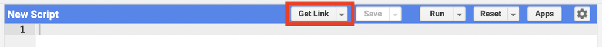

Figure 3. The “Get Link” button.

The **drop-down button** at the right of the **Get Link button** has the option to “Manage Links.” Clicking this button opens a new tab that allows you to access, remove and download previously generated script links. If you choose to download the script, this will be saved to your personal computer as a zipped folder containing a .txt file with the code.

Next to the **Get Link button** is the **Save button**. This button allows you to save the script as a new script and subsequent updates.

Next is the **Run button** that allows you to run the script. The **drop-down button** allows you to run the script with profiler (See Profiler tab below).

To the right, the **Reset button** will reset all tabs on the right panel. The **drop-down button** will allow you to clear the script to start a new one.

Next is the **Apps button**. This opens the App window display that we will explore later on the tutorial.

Finally, there is a **Settings button** that allows you to activate options to underline code suggestions and to auto-complete pairs such as quotation marks, parentheses and brackets. You can activate or deactivate these two options depending on your coding preferences.

#### 2.2.2 The left pannel

##### 2.2.2.1 The Docs tab – API reference

The **Docs tab** (Fig. 4) contains the entire JavaScript API documentation developed by Google. Here, you will find all the information necessary to understand functions. We recommend you to get familiar with this tab as it gets really useful for writing scripts and running more complicated analysis. You can use the search tab to filter methods and find specific functions.

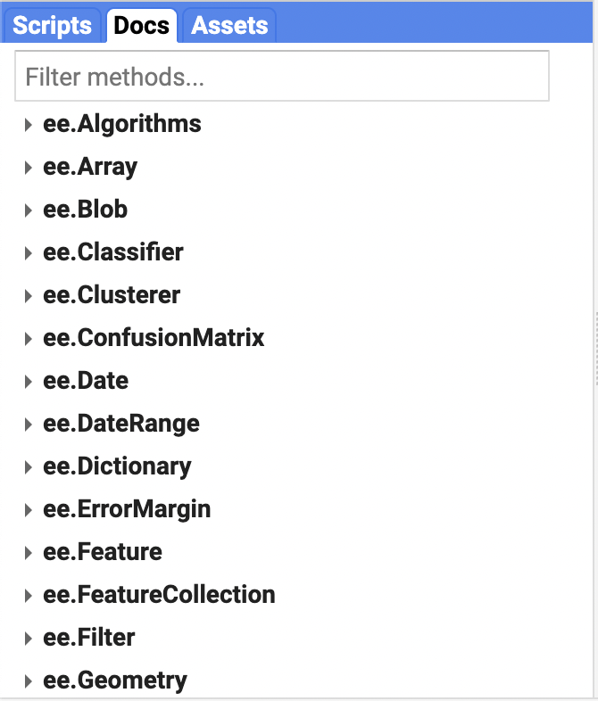

Figure 4. The Docs tab.

When clicking on any build in function, you will find a description of the function, the arguments that the function takes, and the what the function returns.

##### 2.2.2.2 The Scripts tab – Script manager

The **Scripts tab** is where private, shared and all script examples hosted by Google are stored. The **Owner level** stores all your private scripts, the ones that only you can see and edit. The **Writer level** stores scripts that has been shared (access granted) with you by another user. Sharing repositories and scripts can be really useful to work on collaborative projects. Once someone has added you to a repository, you can add new scripts, modify existing scripts, and manage access to the repository for other users. Of course, you can create and share repositories and scripts with other users. The **Reader level** contains scripts for which you have read access granted by the script owner, but you cannot edit the scripts. The **Example level** has script examples created and managed by Google, that are really good for some basic operations. Take a look at the scripts available in this folder. The **Archive level** is for scripts that users have access to read but have not been migrated by their owner from an older version of the Script Manager. The search tab allows you to search for scripts within all these levels.

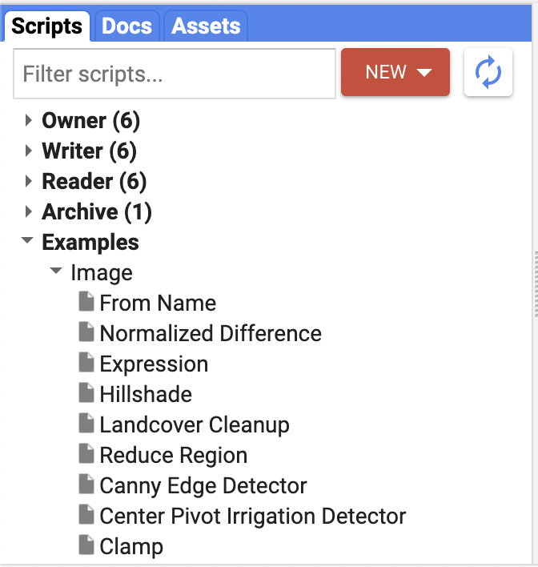

Figure 5. The Scripts tab.

The **New button** allows you to create a new repository in the **Owner folder** or to create folders and files within existing repositories. It is a good practice to keep your repositories and scripts organized. Give folders and scripts proper names, something that you will be able to recognize after several months of not working on them. Your brain can forget things pretty quick. Once you have created your repositories and scripts, they can be renamed and deleted by the **Rename and Delete buttons** that appear at the right on the script while positioning the pointer on top of the script. Scripts can be dragged and dropped into new folders or copied into new repositories. The **Revision History button** allows to compare with previous versions and recover them. Always important in case that you delete something by mistake. Similarly, positioning the pointer on top a repository allows to delete and access the history of the repository. The **Configure button** allows you to manage access to the repository. As we said before, you can grant access to other users to your repository. Repositories can be configured to be accessed using Git, so you can manage and edit your scripts outside the Code Editor, or sync them with an external system like Git Hub (Fig. 6).

For this tutorial we have created a repository that you can access in the reader level.

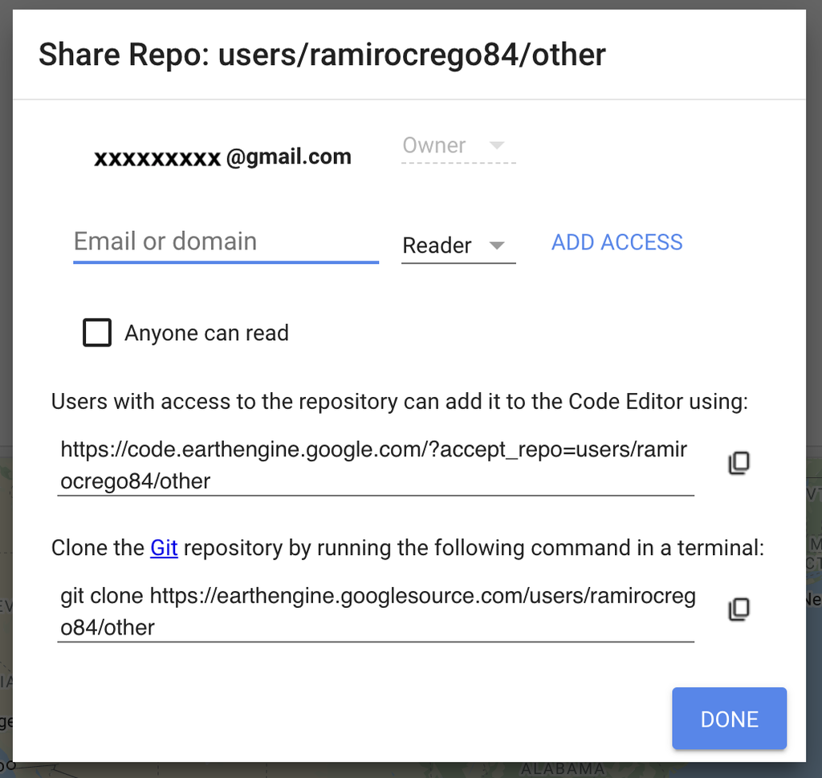

Figure 6. You can manage repositories to share with other users.

##### 2.2.2.3 The Asset tab – Asset manager

The **Asset tab** allows you to upload and manage your own image assets, shapefiles, and CSV files (Fig. 7). You can click on **NEW** to upload new assets from your personal computer. We will learn how to do this with later examples in the following sections. For now, it is good to get familiarized with the different parts of the interface.

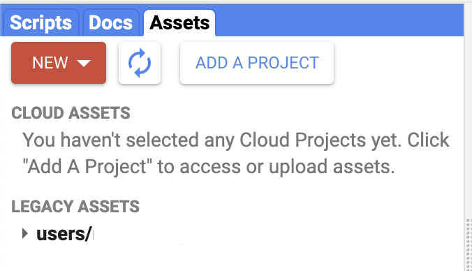

Figure 7. The Asset tab.

#### 2.2.3 Search bar tool

The **search bar** located in the top of the Code Editor that says ‘Search places and data sets…’ allows you to search the GEE data archive. Here you can type different keywords of data products, sensors or places, to filter the data base. If you search for a place, clicking on the place will make it visible in the map. If you search for a data product, such as Landsat, you will see a detailed description of each one. Click **Import** to add the data product into your script as an import (Fig. 8), which will appear at the top of the script. It is also possible to import data products using code, so you do not have to search and click the **Import** button if you want to reuse the script for another work. Additionally, you can see the JavaScript code to import any product by clicking on the copy button next to the code and pasting it into your script. You can delete imports you have added to your script by positioning your pointer next to the import and clicking the delete icon.

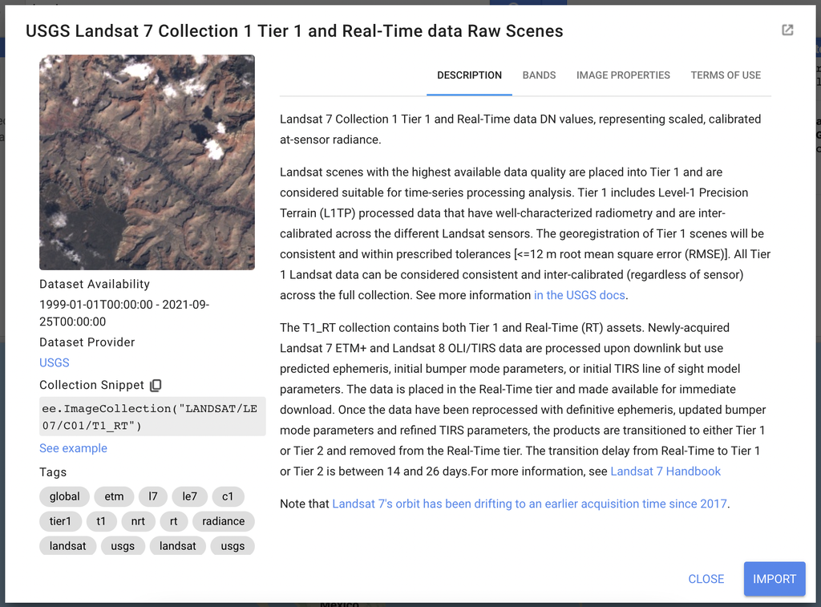

Figure 8. Example of product desription on Google Earth Engine.

#### 2.2.4 The right panel

##### 2.2.4.1 Inspector tab

The **inspector tab** allows you to interactively query the different map layers you have displayed (Fig. 9). When you clicking on the tab, the pointer becomes a crosshair, meaning the function is activated. You can click now on any part of the map and the tab will display the location and values of all layers on the map. This can be useful to inspect the values of your layers across different locations when performing an analysis or when inspecting different layers in any area of interest.

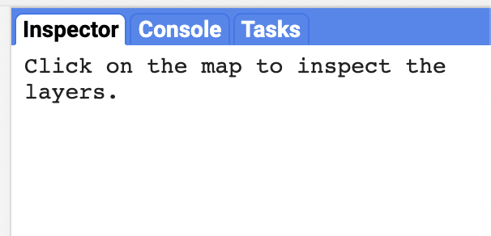

Figure 9. The inspector, console and task tabs.

##### 2.2.4.2 Console tab

The **console tab** is located next to the **inspector tab** (Fig. 9). This tab is where all the information you print on the code will be displayed. We will see later how to print information when using JavaScript. For now, it is enough to remember that this is the tab in which you will interact with the data and where you can display information and results from operations. Those can be text, objects or charts. This console tab is interactive, meaning that you can expand printed objects to get more details about them. We will start to use this tab in the next section when you start writing your first JavaScript code.

##### 2.2.4.3 Tasks tab

The **tasks tab** is located next to the console tab. This tab will display long running tasks when exporting products from your analyses. Those could be images or feature collections. Once the export was called from the code editor, you will need to run it by clicking the run button next to the exported task. A dialog window will appear, which allows you to configure your export. Once you have run the task, the status will display. Tasks can be canceled while running by clicking on the spinning icon next to the task.

#### 2.2.5 Profiler

The **profiler** is a tab that will appear next to the task tab on the right upper panel when you run the script with the run with profiler option (or the shortcuts, holding down Alt for PC or Option for Mac, and clicking run, or pressing Ctrl+Alt+Enter/control+option+return). The tab displays information about CPU time, memory consumed and other computation parameters by the algorithms run and the display of all layers in the map. This can be useful to understand why a script is running slow or failing due to memory limitations. Not too important at the beginning, but something to keep in mind for when you start to me more advanced with Earth Engine analyses. Each row in the profiler tab corresponds to each algorithm, computation, or asset loaded as described in the **Description** column. The count column indicates the proportional number of times the operation was invoked, and the compute column indicates the CPU time taken by the operation. The **Peak Mem** column indicates the maximum memory used on any single computation node for the operation. The **Current Mem** appears only when there is an error given memory limitation and shows the amount of memory that was in use on any single compute node when the error occurred.

#### 2.2.6 The interactive map panel

##### 2.2.6.1 Layer manager

At the top-right corner of the interactive map panel is the **layer manager** that allows you to adjust the display of all layers you added to the map. From here you can activate and deactivate layers display and adjust its transparency with the slider. By clicking the setting icon, you can adjust the visualization parameters of each individual layer (Fig. 10). From here you can customize the stretch of pixel value display, adjust opacity (transparency), adjust gamma display and change the color palette. You can manually choose different colors. Click Apply button to apply the new visualization parameters to the current display. You can also use the Import button to load the new visualization parameters object as a new variable in the imports section of your script that you can use to display other layers on the interactive map.

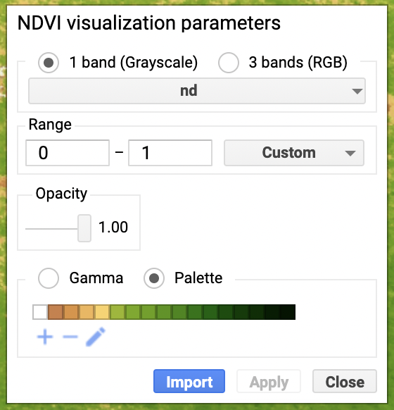

Figure 10. Visualization parameters for layers displayed on the map.

At the right of the **layer manager** are buttons to choose different map backgrounds: Google street view, terrain view or satellite view with the option to activate labels. Another icon allows you to get into a full-screen view.

##### 2.2.6.2 Geometry tools

In addition to images, you can import geometries (i.e., vector data in Earth Engine language) to your script by drawing them on the map. To create a geometry, use the **geometry drawing tools** in the upper-left corner of the interactive map panel. There are four different geometries you can create: points, lines, polygons, and rectangles. When using the drawing tool, any geometry created will automatically create a new geometry layer in the import section of your script. Place the pointer on the **Geometry Imports** button and then click the **+new layer** link. Then choose the type of geometry you want to draw and start clicking on the map to draw your geometries. In the case of polylines and polygons, double click to finalize the drawing. Geometry display on the map can be activated and deactivated from the **Geometry Imports** section. We will learn more about geometries in the second section of this tutorial. You can delete geometries by activating them using the hand tool, and pressing **Delete** on your keyboard or by directly clicking the **delete button** on the **Imports section** of the script.

You can configure the way geometries are imported into the script by using the settings button that appears when positioning the pointer on top of the geometry on the **Geometry Imports** section. After clicking settings, a dialog box will be displayed (Fig. 11). Note that geometries can be imported as geometries, feature or feature collections and you can choose on the button that appears on the box. We will learn more about this in the next section. You can also modify the name and the color of the layer. Finally, you can click the lock button to lock and unlock the geometry, what can be useful to prevent edits or deletions by accident.

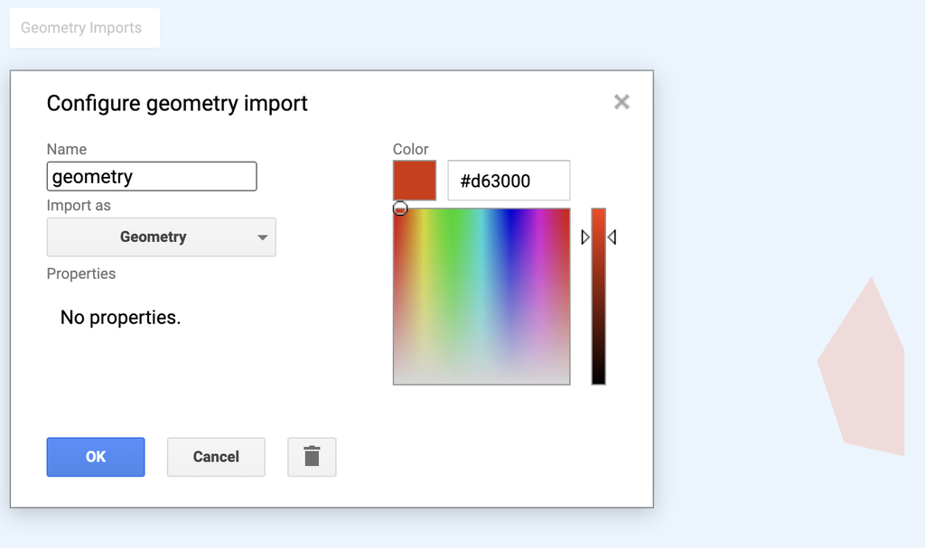

Figure 11. Dialog box for geometries.

#### 2.2.7 The help button

On the upper-right corner of your browser window you will find a help button. When clicking it, you will find links to the developer user guide with more detail information about all we just covered ([link](https://developers.google.com/earth-engine/guides/getstarted), and also links to forums where users post questions and help each other. These forums are of great help and you can post your own questions. Before posting questions make sure to do a good search as there is a good chance that someone else encounter a similar problem before and the answer to your problem is already there.

### 2.3 The data catalog

One of the most notable features of Google Earth Engine is the enormous amount of data available to be used. The database consists on about a petabyte-scale archive of publicly available remotely sensed imagery and other related data sets. It includes products from the most popular satellites such as Landsat, MODIS, National Oceanographic and Atmospheric Administration Advanced Very High Resolution Radiometer (NOAA AVHRR), Sentinel 1, 2, 3 and 5-P; and Advanced Land Observing Satellite (ALOS), and other data such as precipitation data, sea surface temperature data, CHIRPS climate data, topography data, and land cover data (Gorelick et al., 2017). This database increases daily as new satellite imagery is taken, processes and uploaded. New products are also being uploaded frequently. You can explore the data sets at the following [link](https://developers.google.com/earth-engine/datasets/).

In addition to GEE, there is an online community working collaborating further to distribute open source data. New products and datasets are constantly being uploaded and can be find in the following [link](https://samapriya.github.io/awesome-gee-community-datasets/projects/grip/). Also, a weekly list of new products updated to GEE can be found in the following [GitHub repository](https://github.com/samapriya/Earth-Engine-Datasets-List).

### 2.4 A brief intro to JavaScript for Google Earth Engine

In this first section we will learn the basics of JavaScript coding. There are certain code statements that are proper of GEE. We will later dive into those specifics.

The code on this section can be found [here](https://code.earthengine.google.com/2d5cd3a88c5cf465313f272611056afb)

#### 2.4.1 The basics

The code editor panel on the interface is probably the one that you will use the most. If this is the first time you are facing a coding language to perform data analysis, the recommendation is to take it slow. As you get familiarized with the code structure and functions, things will get easier, we promise.

Let’s start with a simple JavaScript statement. Go to the code.earthengine.google.com and type into the code editor panel:

```javascript
print('This is my first code');
```

After, click **Run**. The text ‘This is my first code’ will appear on the **Console tab**. The parenthesis is used to pass arguments to functions. Here print is the function that prints the argument on the console.

In JavaScript, each statement ends in semicolon (But if you do not write it, the code will run anyway, but it may help you to keep your code organized). You will learn to write entire analysis that will be composed of multiple statements like that one.

It is really important that you keep your code organized and knit. One way of doing this is by commenting your code statements. Add `//` before the text you want to add after the statement. For example:

```javascript
print('This is my first code'); //This is my first statement to print text
```

JavaScript will read the first section of the statement, but will omit all the text that comes after the `//`. You can also comment out statements by placing `//` at the beginning of it. This will prevent the statement from running without having to delete it from the code.

```javascript
//print('This is my first code');
```

> A note of writing your script: As you continue working on your script, you will add new lines of code. In Earth Engine, every time you click **run** the entire code will be computed. If there is an error in some line, the computation will end up there and an error message will be prompted in the console pointing to the line number that has the error that stopped the code from continuing processing. You will need to debug and fix the error for the entire script to run successfully to the end.

JavaScript works with objects that you can store and later use in other operations. You can save objects using `var` at the beginning of the statement followed by a name for the objects. There are several types of data types that JavaScript recognize and that we can use: strings, numbers, list and dictionaries.

Strings are text that are defined by single or double quotes (but never mix them). Generally, it is preferred to use single quotes. You can make a string and store it as a new object called myfirststring and print it.

```javascript
var myfirststring = 'This is my first code';
```

Numbers can also be saved as objects.

```javascript
var number = 57;
```

Now we can pass this object to the function `print`. But this time, we are giving two arguments to the function as follows:

```javascript
print('My favorite number is:', number);
```

When looking in the console, now the string and the number have been printed.

Another useful data type are lists. Lists are defined using brackets `[]`. For example, we can create a list of numbers.

```javascript
var myfirstlist = [0,1,2,3,4,5,6];
print('This is my first list of numbers:', myfirstlist);
```

Or also a list of strings.

```javascript
var list2 = ['a','b','c','d'];
print(list2)
```

We can also create arrays, that will add another dimension to the list. We use brackets to define each dimension. The first brackets define the columns of first dimension and the second brackets (inside the first ones) define the rows or second dimension.

```javascript
var myfirstarray = [[1,2],[3,4],['a','b']];
print (myfirstarray);
```

Note that we have mixed numbers and strings here.

Dictionaries are composed of pairs of keys and values and they are made using curly brackets `{}`. When defining a dictionary, you need to specify the key (a name) and the value (e.g., a number, a string, a list), separated by a colon. Add comma after the first pair of key and value if you want to have more than one. For instance:

```javascript
var myfirstdictionary = {
      first: 1,
        second: 'a string',
        third: [1,2,3,5,8,12]
    };

print (myfirstdictionary);
```

One important feature of dictionaries is that you can access the dictionary items suing square brackets or dot notation:

```javascript
print(myfirstdictionary['first']);
print(myfirstdictionary.first);
```

Dot notations are handy in JavaScript coding architecture. We will use it more frequently when running different functions in a line of code.

#### 2.4.2 Functions

Now that we have seen the different data types, we are going to start building and using functions. Functions allow to perform a myriad of operations. While, there are multiple functions that are already built within Earth Engine (Remember the **Code Editor Docs** tab to see all built-in functions), sometimes it is useful to create your owns. Moreover, understanding the basic components of a function will help you understand all the built-in ones. Functions need to be stored as variables as before. Functions are defined with the keyword `function` followed by parentheses within which you can define different parameters on which the function will operate. After the parentheses, follow the statements that make up the function and go inside curly brackets. The last statement is `return`, which indicates the output of the function.

```javascript
var myfirstFunction = function(parameter1, parameter2) {
    statement1;
    statement2;
    return statement;
  };
```

There is no limit on the number of parameters that a function can take, and it can also use variables declared outside the function.

For example, we can build a function that adds 2 to a number. We will name the function add2

```javascript
var add2 = function(number) {
      var result = ee.Number(number).add(2);
      return result;
    };
print('Result of add2:',add2(4)); //Adds 2 to the number 4
```

#### 2.4.3 Engine objects

So far, we have been using JavaScript code working with our computer processor, also known as the *client side*. However, we are going to be using Google computing infrastructure to run operations, rather than the processor of your own computer, or the *server side*. Thus, we need to create objects that can be sent in a form that is understood by Google servers. These are the **Earth Engine objects**. These are written in the form of `ee.thing` with thing being a data type, also known as containers. Maybe, you noticed that in the previous function, we specified `ee.Number` so that Google Server could compute the sum.

Now on, in order to created variables, we are going to assign those variables to the corresponding container, which depends on the data type, so that Google can recognize it and operate on it.

For strings, we have the `ee.String()` container

```javascript
var simpleString = 'Text to send to server';
var eeString = ee.String(simpleString);
print('This is:', eeString);
```

Now the print() function will send the container to Google server to be evaluated, and then is sent back to your computer, where the container is opened to be displayed.

Similarly, for numbers we use `ee.Number()`, for lists `ee.List()` and so on. The `ee.Thing` are constructors that take arguments and parameters to be processed by Google servers and returns a container with a Earth Engine object that you can manipulate, export, print or plot in your code.

Note that print, Map, Chart, and other function we will use are on the *client side*. They run on your computer, not on Google servers. WE will see next how to operate Google objects on the *server side*.

#### 2.4.4 Working with Earth Engine objects

Now we have seen how to create objects that Google servers can read and process. It is important to incorporate this concept because it will be critical for developing more complicated codes.

Once you have created an Earth Engine object, then JavaScript operations will not work, instead you have to use operations defined for those Earth Engine objects. Thus, while we are using JavaScript to code, we are now going to use a specific set of functions created to operate on Google Earth Engine. On the **Doc tab** on the top-left panel, you can find all the methods and functions available to work with Earth Engine objects.

Within the built-in function set, you will find a variety of useful functions that will make your work easier. For example, you can create a sequence of numbers using `ee.List`:

```javascript
var eeList = ee.List([1, 2, 3, 4, 5]);
```

But also you can use the built-in Earth Engine function sequence, to create the same variable:

```javascript
var sequence = ee.List.sequence(1, 5);
```

```javascript
var value = sequence.get(2);
print('Value at index 2:', value);
```

One important aspect to consider when accessing variables created with Earth Engine functions is the data type. Many times, the object that returns from a specific function does not come with a data type assigned. Consequently, when trying to operate on those new variables, you will get an error stating that the argument is not a function. For instance, if you try to add a number to the value extracted from the sequence in the previous step, you will get an error saying *value.add is not a function*.

To avoid this problem, you need to reassign the corresponding container for the specific data type, in this case a `ee.Number`:

```javascript
print(ee.Number(value).add(5));
```

This process is known as casting.

#### 2.4.5 Earth Engine dictionaries

Dictionaries can be really useful in Earth Engine. Similar to the JavaScript dictionary, we can create Engine containers for dictionaries using `ee.Dictionary` and specifying the different keys. Lets create a dictionary containing keys for a species information:

```javascript
// Create an Earth Engine dictionary
var dictionary = ee.Dictionary({
    Common_name: 'Tiger',
    Genus: 'Panthera',
    Species: 'Panthera tigris'
  });

// Get the species name from the dictionary.
print('Species:', dictionary.get('Species'));

// Get all the keys:
print('Keys: ', dictionary.keys());
```

Note that with the Earth Engine dictionary, now you cannot access the elements using JavaScript code as before. You need to use an Earth Engine function with Earth Engine objects. To extract a key you need to use the function get. Remember, as we explained before, the returning objects does not have an data type specified, and you will need to specify `ee.String` to use the object in another Earth Engine function. Finally, you can also use the function `keys` to extract all keys, and the resulting objects is going to be an `ee.List`.

#### 2.4.6 Passing arguments to functions by name

```javascript
Map.setCenter(99.2, 12.6, 6);
```

Or you can pass the arguments using a dictionary to visualize the name of the arguments:

```javascript
Map.setCenter({lon:99.2, lat:12.6, zoom:6});
```

The arguments by name can be in any order:

```javascript
Map.setCenter({lon:99.2, zoom:6; lat:12.6});
```

#### 2.4.7 Dates in Google Earth Engine

Many times you will find yourself working with data and imageries from different times that you will need to filter. To manage time in Google Earth Engine, you need to use date Earth Engine objects using `ee.Date`. You can construct an `ee.Date` object using a string to specify the date:

```javascript
// Define a date in Earth Engine.
var today = ee.Date('2020-6-9'); //This is a year/month/day format
print('Today is:', today);
```

You can also use another less orthodox method that is using a JavaScript Date that represents milliseconds since midnight on January 1, 1970. This seems strange at first, but you will see later on that it becomes handy for multiple operations.

```javascript
// Get current time using JavaScript Date
var now = Date.now();
print('Milliseconds since January 1, 1970', now);
```

Later in this tutorial, we will explore different functions to filter data sets by date or use data in more complex analysis.

#### 2.4.8 Final notes on operations

We saw how to package objects created in the *client side* into containers to be used on the *server side*, the ee.Thing. Sometime, however, you may need to convert earth engine objects into client-side objects. In this case, you can open the container to access its information using `.getInfo()`. Another method is using the function `evaluate()`, which retrieves the values inside the earth engine objects. This is strictly not recommended by Google, so you need to use only when it is absolutely necessary. The difference with `.getInfo()` is that the later will stop the rest of the code from continuing processign until all information is retrieved from the Earth Engine object, whereas `evaluate()` will allow other porcesses to continue operating.

Retrieving the information in the containers and mixing the client and server side is not recommended by Google, and you should only use it when absolutely necessary. It is always better to operate on the server side. Check the [Google user guide](https://developers.google.com/earth-engine/guides/client_server) to learn more about this.

#### 2.4.9 Data structures in Google Earth Engine

We have seen so far some important data structures in Earth Engine, *String*, *Number*, *Array*, *List*, *Dictionary* and *Date*. Those are fundamental blocks of Earth Engine code. However, in Google Earth Engine we will be working with geospatial data, thus, two other important geographic data structures are *Image* and *Feature*. These two data structures correspond to the raster and vector data types. Images are composed by a combination of bands and a dictionary with properties and features by a combination of a geometry and dictionaries with properties. If you are not familiar with raster and vector data, this is a good moment to refresh those concepts before you continue with the next section.

### 2.5 Conclusion

In this first section we have cover an overview of the Google Earth Engine platform. By now, you should have an account set and be familiarized with the web-based interface. We have also seen the basics of JavaScript coding language and how it works within Earth Engine. In the following section we will start using some data and learn how to work with it.

For a more in depth description and tutorials to use GEE, remember to visit the [Google Earth Engine guide](https://developers.google.com/earth-engine/guides?hl=de) and [tutorials](https://developers.google.com/earth-engine/tutorials?hl=de).

### 2.6 References

Gorelick, N., Hancher, M., Dixon, M., Ilyushchenko, S., Thau, D., & Moore, R. (2017). Google Earth Engine: Planetary-scale geospatial analysis for everyone. Remote Sensing of Environment, 202, 18–27. https://doi.org/10.1016/j.rse.2017.06.031

C.E. Woodcock, R. Allen, M. Anderson, A. Belward, R. Bindschadler, W. Cohen, F. Gao, S.N. Goward, D. Helder, E. Helmer, R. Nemani, L. Oreopoulos, J. Schott, P.S. Thenkabail, E.F. Vermote, J. Vogelmann, M.A. Wulder, R. Wynne. 2008. Free access to Landsat imagery. Science, 302 (5879), p. 1011

Michael A. Wulder, Thomas R. Loveland, David P. Roy, Christopher J. Crawford, Jeffrey G. Masek, Curtis E. Woodcock, Richard G. Allen, Martha C. Anderson, Alan S. Belward, Warren B. Cohen, John Dwyer, Angela Erb, Feng Gao, Patrick Griffiths, Dennis Helder, Txomin Hermosilla, James D. Hipple, Patrick Hostert, M. Joseph Hughes, Justin Huntington, David M. Johnson, Robert Kennedy, Ayse Kilic, Zhan Li, Leo Lymburner, Joel McCorkel, Nima Pahlevan, Theodore A. Scambos, Crystal Schaaf, John R. Schott, Yongwei Sheng, James Storey, Eric Vermote, James Vogelmann, Joanne C. White, Randolph H. Wynne, Zhe Zhu. 2019. Current status of Landsat program, science, and applications, Remote Sensing of Environment, 225, 127-147, https://doi.org/10.1016/j.rse.2019.02.015.

### 2.7 Assignment 1

In this introductory module we have covered the very basics of programming in Google Earth Engine. In the next module, we will start processing spatial data like images and features. This assignment is an opportunity to internalize some of the basic JavaScript functions that you will build on as you continue to grow your knowledge of GEE.

Here are some exercises that will help you practice your coding skills. For the assignment, you need to create a single functional script with both code and responses to questions. You can add any answers to the questions into your script using comments //

1. In the code editor panel of the Google Earth Engine interface, use JavaScript code to create 3 different objects. You can give any name to these objects, but each object needs to be a different data type. Print your objects in the console by clicking the run button and make sure your code runs without errors.
2. Here is a list of JavaScript code commands. Each line of code contains an error (You can run the line of code to see the error). Find the error and fix it, so the code runs successfully.

```javascript
print(this is my first code);

print(4 + “4”);

var mylist = [0,1,2,a,d,c];
print(mylist)

var number = 45;
print(Number)

var mysecondlist [1,2,4];
print(mysecondlist)

var mydictionary = [
    first: 1,
    second: 'a string',
    third: [1,2,3,5,8,12]
];
print (mydictionary);
```

3. Using the search tab on the Docs panel, find the function add for ee.Number objects. Using this function, add 5 to 5 and store the result as a new variable. Print this variable to the console.
4. It is important that you understand the difference between JavaScript objects and Earth Engine objects. As an exercise, transform the following JavaScript objects into their equivalent Earth Engine object (the ee.Thing).

```javascript
var animal = ‘Tiger’;
var number = 78;
var list = [1,2,3];
```

5. The following function does not work. Find the error and fix it:

```javascript
var multiplyby2 = function(number) {
  var result = number.multiply(2);
  return result;
};
print('Result:', multiplyby2(4));
```

6. Save the script for this assignment.

## 3 Data management in Google Earth Engine

In this second section we will learn how to import, operate and display images and features on Google Earth Engine (GEE). This is the basic building block for any ecological spatial analysis and with time, this set of operations and functions will become a simple habit.

In order to learn the basic procedures and functions to work in GEE, we will develop a simple example. The idea is that after completing this section, you will have a basic understanding on how to change the area of interest, load and work with different data sets (both, images and features) and perform some of the most common functions and operations.

The code on this section can be found [here](https://code.earthengine.google.com/b1c2e2681df2df0f54db5fcf1116bc70)

### 3.1 Getting started

The first step in any project that involves coding is to start and save a script where you can safely keep your work progress. First, using the forward slash to comment out code, write a header to your script, providing general information such as, your name and a title. Something like this:

```javascript
/////////////////////////////////
// My name
// Getting started with GEE
/////////////////////////////////
```

You can also comment chunks of code using a slightly different code: `/* text */` This can be more handy for when you need to activate and deactivate several lines of code at the same time.

```javascript
/*
My name
Getting started with GEE
*/
```

You can choose the method that is easier for you.

After you completed the header, click on the **New button** on the Scripts tab of the left panel. From the dropping menu, chose **File**. This will open a window where you can provide a name and chose the repository where to save your script. Give scripts proper names. You can also provide a brief description of your project if desired. Once you have saved the script for the first time, you just need to click **Save** (Above the code editor panel) every time you want to save updates to the script (Fig. 1).

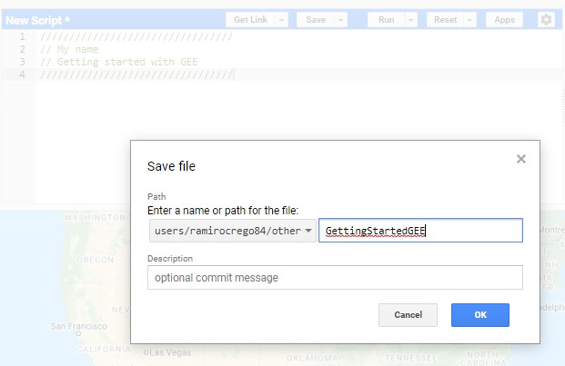

Figure 1. Saving a new script.

As you may recall from the introductory section, you can also create new repositories and folders to keep your work organized and share them with collaborators.

### 3.2 Defining your study area

To position the map display on the area of interest, we will use the function `Map.setCenter()`, for which we need to provide coordinates and a zoom level (higher numbers indicate larger scale or more zoomed in). You may recall this from the previous section.

```javascript
Map.setCenter({lon:35.65, lat:-1.54, zoom:6});
```

The next step is to define a geometry, in this case a rectangle, that will represent the study area. Click on the rectangle icon from the geometry tools and draw a rectangle that covers the area of interest (see Fig. 2). We need to provide a name to the new geometry. Name it StudyArea.

> Hint: You cannot use spaces for names, so we use capital letters or underscores to differenciate words. At the end, it does not matter what name you use, but it is good to use names for variables that you can recognize.

After you finish, the geometry will appear in your imports (top of the script editor) as a polygon with four vertices. We will discuss more about geometries later in this section.

[figure not shown]

Figure 2. Rectangle geometry demarcating the study area

You can rename the geometry and save it as a new object using code:

```javascript
var Bounds = StudyArea;
```

You have now defined the study area. Later, we will use this polygon to clip images and restrict the extent of our analysis.

### 3.3 Working with images

In GEE, raster data are represented as **Image objects** and are the main type of data to work with. All images are composed on one or more bands, where each band has a name, data type, scale, mask and projection, as well as metadata stored as a set of properties. Let’s start working with some simple images.

#### 3.3.1 Loading images

The first step for our workflow is to import an image. Let’s start working with a simple image with one band which contains information about elevation, also known as Digital Elevation Models.

Remember from previous section that you can search for places, images, image collections, and feature collections on the GEE Data Catalog.

To find the elevation data, on the search bar type: ‘SRTM Digital Elevation Data 30m.’ Now, click on it to display the data description where you can find information about the temporal availability, data provider and collection ID (Fig. 3). This data set corresponds to a digital elevation data from the Shuttle Radar Topography Mission (Farr et al. 2007) and contains information of elevation at 30m spatial resolution. You can click **import** to add it to your imports, or you can use code. We encourage you to use code, so you get more familiarized with it and also helps you to keep the work organized.

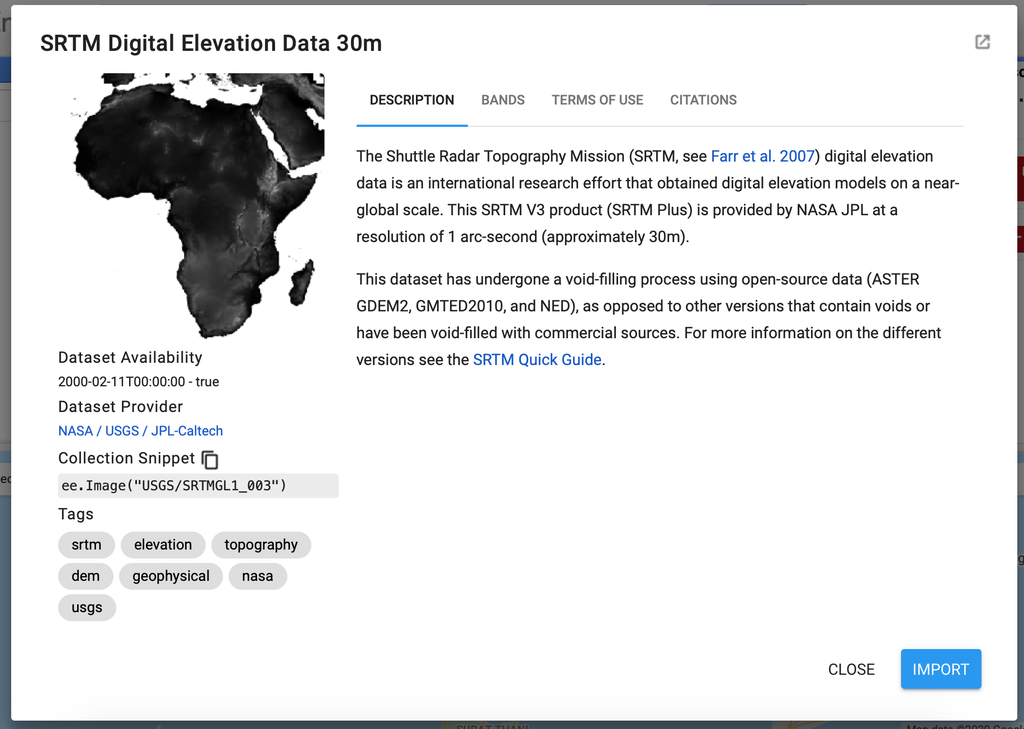

Figure 3. SRTM Digital Elevation Data description.

The function `ee.Image()` allows you to import image catalogs. To import the elevation data, we need to provide the directory to the data within the parenthesis of the function. Remember to assign the image to a new object using **var** as follows:

```javascript
var Elev = ee.Image("USGS/SRTMGL1_003");
```

You have just imported the elevation data for the entire world.

When working in spatial ecology, frequently, slope, aspect and hillshade are variables of interest as many species respond positively or negatively to changes in the terrain surface. Thus, these data sets can be good predictor variables in several models. We only have information about elevation, but you can calculate slope, aspect and hillshade and save them as new objects using other GEE built-in functions.

To calculate all these terrain variables, we will use the built-in function `ee.Algorithms.Terrains()`.

Let’s apply the function to the elevation image and save it as a new object.

```javascript
var Terrain = ee.Algorithms.Terrain(Elev);
```

At this point, you should be familiarized with the code syntax to create objects and use built-in functions in GEE.

Print both elevation images to display the information on the console.

```javascript
print(Elev);
print(Terrain);
```

You will see that differently from the Elev image that contains one band, the new image created (Terrain) contains four bands, one for each variable: elevation, slope, aspect and hillshade. All of these three new bands where calculated from the elevation data. If you want to know more about the algorithms used to obtain these results, remember that for all the Engine built-in functions you can use the API reference on the Docs tab to see a description and all the parameters used by the function. The `ee.Algorithms` category contains a list of currently supported algorithms for specialized or domain specific processing.

Look for the `ee.Algorithms.Terrains()` function in the Docs tab (Fig. 4).

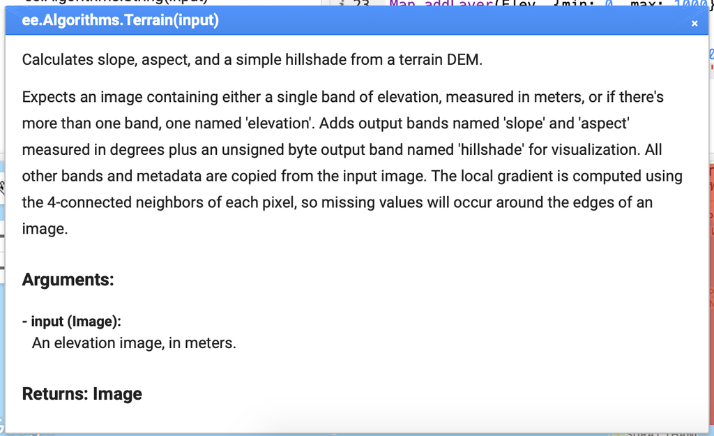

Figure 4. View of the ee.Algorithms.Terrains description in the Docs tab.

This exercise shows you the versatility and power of conducting spatial analysis on GEE. You can in matters of seconds, download elevation data and calculate slope, aspect and hillshade for the entire world!

In many cases, we are only interested in one specific area and not the entire planet. We can use the GEE built-in function `clip()` to crop the image to our area of interest, the polygon we crated earlier.

Using the dot notation, we add the function `clip` to the image object you want to crop, and specifying in between parenthesis the object representing the area of interest we previously created.

```javascript
var Terrain = Terrain.clip(Bounds);
```

You have now an image object cropped to the area of interest.

#### 3.3.2 Displaying data on the map

Often, you will be interested in visualizing the images. To display the elevation data on the map, you can use the function `Map.addLayer()`. To the previous code, now add the function to display the data as follows:

```javascript
Map.addLayer(Terrain);
```

Parameters for functions may have default values, and then, you only need to specify the parameter if you want to change its default value. For instance, the previous function displays a gray surface. You need to change the default parameters for the appearance of the image to be able to visualize elevation change.

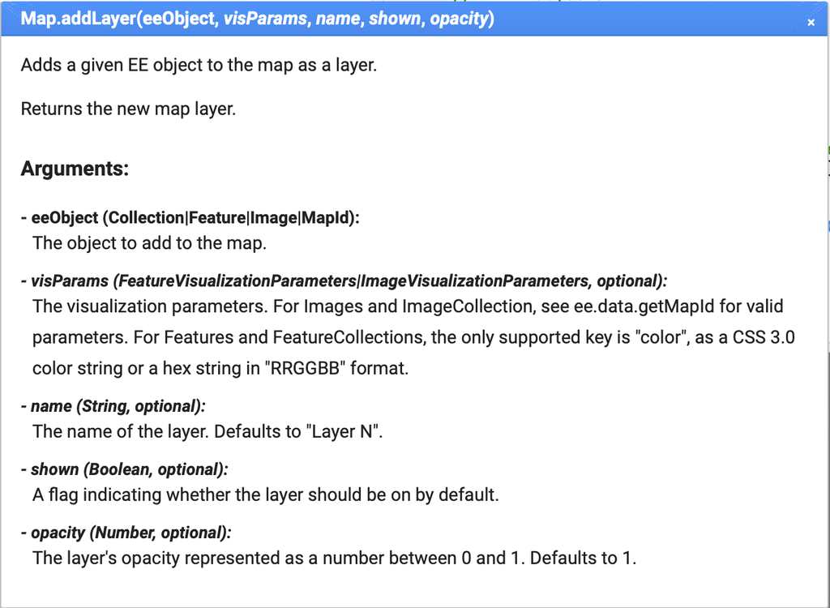

Figure 5. Description of the Map.addLayers function.

```javascript
Map.addLayer(Elev, {min: 0, max: 3000}, 'DEM', 1);
Map.addLayer(Terrain, {bands:['elevation'] ,min: 0, max: 3000}, 'Elevation', 1); //Same as before but from the terrain object
Map.addLayer(Terrain, {bands:['slope'] ,min: 0, max: 10, palette:'white,red'}, 'Slope', 1); //Display slope and add a color palette
```

Note the difference between an image that was cropped and the one that was not cropped. Play with the image visualization using the Layers button in the display.

#### 3.3.3 Image collections

We have so far worked with a single image. Now, we are going to access an entire image collection. Image collections can contain hundreds of images across long periods of time, such as images from satellites. Similarly to the elevation image, you can search for image collections. Let’s access the image collection of Landsat 8. Landsat images come with different levels of pre-processing. Here we will work with T1, that is the highest level of pre-processing.

Use the search bar to find the name of the Landsat 8 T1 image collection and import it using the function `ee.ImageCollection()`.

```javascript
var landsat8 = ee.ImageCollection("LANDSAT/LC08/C02/T1")
```

You just imported the entire image collection of Landsat 8 for the entire Earth land surface. You could try to print the image collection to see all the images contained in the list. However, because there are too many images, printing it will either be very slow, time out, or return an error.

#### 3.3.4 Filtering and sorting

What we need to do to work with image collections is to filter them and reduce the number of images in the list to the ones that we are interested in. To do this, we will use filters.

Filters are a set of functions that allows you to select a set of images based on certain parameters such as position, time windows, numbers, properties, depending on the type of object you are trying to filter, such as image collections, feature collections, lists or geometries. Lets see how this works for image collections.

```javascript
var landsat8 = ee.ImageCollection("LANDSAT/LC08/C02/T1")
    .filterBounds(Bounds)
    .filterDate('2023-01-01', '2023-12-31')
```

In addition, we are interested in finding images that are cloud-free. Here we will use another function to solve this problem. All Landsat images contain information about cloud cover in the metadata. We can use this information to sort the image collection from lowest cloud cover to highest cloud cover using the function `sort()`, which operates on the image metadata. You could apply a new function to the object created with the previous line of code. You can also simplify things by concatenating functions in the same line of code, again using the dot notation.

```javascript
var landsat8 = ee.ImageCollection("LANDSAT/LC08/C02/T1")
    .filterBounds(Bounds)
    .filterDate('2023-01-01', '2023-12-31')
    .sort('CLOUD_COVER', true);

print(landsat8) //The image collection contains 106 images
```

You can save the first image (lowest cloud cover) as a new object and display it. This time, you are displaying an image composed by a series of bands and the final color display depends on the combination of bands assigned to the tree main colors, red, green and blue. If you assign the bands corresponding to the three colors, then you obtain a true color display. You can also try a false color composition or displaying just the thermal band.

```javascript
var first_image = landsat8.first();

print(first_image)

// Display image
// True color
Map.addLayer(first_image, {bands: ['B4', 'B3', 'B2'], min: 7000, max: 13000}, 'Landsat8-RGB', 1);
// False color
Map.addLayer(first_image, {bands: ['B5', 'B4', 'B3'], min: 7000, max: 13000}, 'Landsat8-FalseColor', 1);
// Thermal
Map.addLayer(first_image, {bands: ['B10'], min: 27000, max: 37000, palette: ['blue', 'red', 'orange', 'yellow']}, 'Landsat8-Thermal', 1)
```

As always, you can access the complete GEE filtering functionality by tipping `ee.Filter` into the search bar of the **Docs tab**.

#### 3.3.5 Reducing

We have so far selected and printed the first image of the list. Now we want to create a full mosaic of the study area with images that are free of clouds. The reduce function allows to reduce image collections to a single image. It is a way to aggregate data over time (`imageCollection.reduce()`), space (`image.reduceRegion()`, `image.reduceNeighborhood()`) or bands (`image.reduce()`).

The `ee.Reducer()` can be a used to operate a simple statistic for aggregating data (e.g. minimum, maximum, mean, median, standard deviation, etc.), or for more complicated analysis on the input data (e.g. histogram, linear regression, list). In all these cases, the reducer takes an input data set and calculates a single output. When a single input reducer is applied to a multi-band image, such as Landsat image, GEE automatically applies the reducer separately to each band, producing an output image with the same number of bands as the input.

```javascript
var l8_mosaic_1 = ee.ImageCollection("LANDSAT/LC08/C02/T1")
    .filterBounds(Bounds)
    .filterDate('2023-01-01', '2023-12-31')
    .filterMetadata('CLOUD_COVER', 'less_than', 10)
    .reduce(ee.Reducer.median());

print(l8_mosaic_1)
```

The reducer is going to change the name of the bands. When printing the image, you can see that the band names have changed (Fig. 6).

[figure not shown]

Figure 6. Band names for the mosaic after applying a median reducer.

Instead of using the reducer, you can use the built-in function `median()` that will do the same operation on each pixel across the stack of all matching bands but retain the original band names.

```javascript
var l8_mosaic_2 = ee.ImageCollection("LANDSAT/LC08/C02/T1")
    .filterBounds(Bounds)
    .filterDate('2023-01-01', '2023-12-31')
    .filterMetadata('CLOUD_COVER', 'less_than', 10)
    .median();

Map.addLayer(l8_mosaic_2, {bands: ['B4', 'B3', 'B2'], min: 7000, max: 12800}, 'Landsat8-Mosaic', 1);
```

As we develop more complex analysis along the tutorial, we will learn more specifics on the reducer functions. You can look into the `ee.Reduce` methods that exist in the API.

#### 3.3.6 Band math

To demonstrate the versatility of GEE to perform mathematical operations on images, we will calculate NDVI using different methods.

Some simple image math can be performed by using `add()`, `subtract()`, `divide()`, `multiply()`, `pow()`, etc. Those operators can be applied on numbers, images or arrays. We can use these operators to calculate NDVI.

First, we need to `select` the desired bands from the image and then apply the mathematical operation. For our example, we need the red band (band 4) and the near infrared band (band 5):

```javascript
// Method 1 - Applying band operations
var ndvi_1 = l8_mosaic_2.select('B5').subtract(l8_mosaic_2.select('B4'))
      .divide(l8_mosaic_2.select('B5').add(l8_mosaic_2.select('B4')));
```

However, it is generally the case that you need to perform more complicated mathematical operations. For those cases, you can use the `expression()` function, which allows to represent math operation in text forms.

```javascript
// Method 2 - Applying band opperations using a expression
var ndvi_2 = l8_mosaic_2.expression('(B5 - B4) / (B5 + B4)', {
        B5: l8_mosaic_2.select('B5'),
        B4: l8_mosaic_2.select('B4')
    });
```

Note that `expression()` returns an integer if two integers are divided, so that the expression 10 / 20 = 0. To obtain decimal numbers as results, you need to have decimal numbers in the operations. For instance, in the previous case, you have to multiply one of the operands by 1.0: 10 * 1.0 / 20 = 0.5.

For many basic operations, such as calculating vegetation indexes, often exists a built-in function in Earth Engine that makes things much easier. Here, we will use the `normilizedDifference()` function. We need to provide the name of the two bands to use.

```javascript
// Method 3 - Using a built-in function
var ndvi_3 = l8_mosaic_2.normalizedDifference(['B5', 'B4'])
```

Finally, it may be the case that you want to write your own function. The advantage of writing a function is that you can then apply the function to any image you want to work with. Here, we are going to write a function that calculated NDVI (function `normilizedDifference()`), renames the resulting band as NDVI (function `rename()`) and adds it to the image as a new band (function `addBands()`).

```javascript
// Method 4 - Building your own function to compute NDVI and add it as a new band to the image
var addNDVI = function(image) {
var NDVI = image.normalizedDifference(['B5', 'B4']).rename('NDVI')
    return image.addBands(NDVI) //with addBands, the new NDVI is added as a new band to the existing bands.
    };

// Apply the function to the mosaic
var l8_mosaic_3 = addNDVI(l8_mosaic_2);
```

You can also use the function `map()` to apply the addNDVI function you have created to an entire image collection. As a result, all the images on the collection will have an additional band called NDVI.

```javascript
var l8_NDVI = ee.ImageCollection("LANDSAT/LC08/C02/T1")
    .filterBounds(Bounds)
    .filterDate('2023-01-01', '2023-12-31')
    .filterMetadata('CLOUD_COVER', 'less_than', 10)
    .map(addNDVI);
```

#### 3.3.7 Masking

Another common operation when working with images is masking. Masking refers to setting certain pixels from an image to no data values (i.e., making them transparent) in order to exclude them from analyses. Masking is usually done to remove pixels with poor data, representing clouds or any other area that wants to be excluded.

Every pixel in a band of an `ee.Image`, in addition to its value, has a mask which ranges from 0 (i.e., no data) to 1. In Earth Engine, all masked pixels (0) are treated as no data. When applying a mask, pixels with a value of 0 are then excluded from operations. For instance, when applying `image1.mask(image2)`, the values of image2 are taken and used as a mask of image 1, meaning that pixels in image2 that have the value 0 will be made transparent in image1.

Continuing with our example, we may be interested in removing all the water from the NDVI image. We need to create a mask that will retain only the land pixels (Fig. 7).

[figure not shown]

Figure 7. Masking process.

```javascript
// Create a land mask using surface water dataset.
var watermask =  ee.Image('JRC/GSW1_4/GlobalSurfaceWater').select('max_extent').eq(0);

// Update NDVI mask with the land mask.
var maskedndvi_1 = ndvi_1.updateMask(watermask);

// Display the masked result.
Map.addLayer(maskedndvi_1, {min:0, max:1}, 'NDVI masked');
```

Masks can be particularly useful in cases where you cannot find images that are cloud free and you need to mask those pixels for analysis.

### 3.4 Working with features

In addition to the raster datasets, we can use vector data in GEE. Vector data is handled with the Geometry type. Geometries in Earth Engine can be **Point** (a list of coordinates in some projection), **LineString** (a list of points), **LinearRing** (a closed LineString), and **Polygon** (a list of LinearRings where the first is a shell and subsequent rings are holes). **MultiPoint**, **MultiLineString**, and **MultiPolygon** are also supported.

#### 3.4.1 Geometries and features

You can create Geometries using the Code Editor geometry tools, as you did at the beginning of the section to define your study area. However, you can also use code to create geometries, by providing a list of coordinates. The following code will create the polygon representing the study area defined earlier. All we need is a list of pair of coordinates, indicating the vertices of the polygon. Check that the first and last coordinates are the same.

```javascript
var polygon = ee.Geometry.Polygon([
  [[34.20, -2.46], [41.63, -2.46], [41.63, 4.07], [34.20, 4.07], [34.20, -2.46]]
]);
```

Geometries can then be converted into features. A **Feature** is an object with a geometry property storing a **Geometry** object (or null) and a **property** storing a dictionary of other properties. In order to create a feature, you need to provide a geometry, but also a dictionary with other properties of interest.

```javascript
var polyFeature = ee.Feature(polygon, {Area: 'Kanya'});
```

**Geometry** and **Feature** objects can be printed or added to the map similarly to images using `Map.addLayer()`. The default visualization parameters will display vectors with solid black lines and semi-opaque black fill. You can change the colors similarly to images.

```javascript
print(polyFeature);
Map.addLayer(polyFeature, {}, 'Study area');
Map.addLayer(polyFeature, {color: 'red'}, 'Study area - red');
```

#### 3.4.2 Feature collections

Similar to image collections, you can create a feature collection, that is as the name implies, a collection of features. To do this, we need to apply `ee.FeatureCollection()` on a list of features. For instance, we can create a list of feature points, each of which represents a town with its coordinate (the geometry) and a dictionary with the name of the town. We can then combine all the town into a feature collection.

```javascript
// Make a list of Features
var feature_list = [
  ee.Feature(ee.Geometry.Point(36.07,-0.29), {name: 'Nakuru'}),
  ee.Feature(ee.Geometry.Point(36.82,-1.29), {name: 'Nairobi'})
];

// Create a FeatureCollection from the list, print it and display it on the map
var Towns = ee.FeatureCollection(feature_list);
print(Towns);
Map.addLayer(Towns, {color: 'blue'}, 'Towns');
```

Google Earth Engine offers several **Feature collections** through the Data Catalog that can be imported. They are mostly data sets for the USA but, in addition to the protected areas we used, there are also country boundaries and ecoregions, among others. This is a much smaller catalog than the one for image collections, but the amount of data available grows every day.

#### 3.4.3 Filtering feature collections

Feature collection can be large, and similar to image collections, we may need to filter them. We will also use filters to do this. Here, we will load the World Database on Protected Areas and filter it to our study area, similarly to what we did before to filter the Landsat image collection.

```javascript
// Load a FeatureCollection of World Database on Protected Areas.
var PA = ee.FeatureCollection('WCMC/WDPA/current/polygons');

// Filter the ecoregions to the study area
var PA_filtered = PA.filterBounds(Bounds);
```

You can now check how many protected areas are within the study area by using `size()` which returns the number of entries in a dictionary.

```javascript
print('Count after filter:', PA_filtered.size());
```

Now, let’s filter the protected areas on our study area that are IUCN category I and II. We can use the `ee.Filter.inList()` function to retain only those protected areas designated as IUCN Category I and II and check how many there are. For the `ee.Filter.inList()` function, we need to pass two arguments, the name of the property we want to filter, and a list of names.

```javascript
// Filter to get only IUCN Cat I and II
var NatParksIUCNIandII = PA_filtered.filter(
  ee.Filter.inList('IUCN_CAT', ['Ia','Ib','II'])
  );
// Ia = strict nature reserve
// Ib = wilderness area
// II national park

// Check the number of parks after filtering
print('Number of IUCN Cat I and II Parks:', NatParksIUCNIandII.size());
```

Finally, lets filter the dataset to retain only the Masai Mara reserve boundary. Here, we will use the `ee.Filter.eq()` (eq for equal) function. As before, you need to provide the property name of the feature to filter on and the value to compare against.

```javascript
var Mara = PA_filtered.filter(ee.Filter.eq('NAME', 'Masai Mara'));
```

#### 3.4.4 Mapping functions over feature collections

Similar to what we learned about mapping functions over image collections, we can do it on feature collections. Let’s say you are interested in calculating the area of each filtered National Park. We will do this as an exercise even though the Protected Area database already has a property with the area of each feature.

First, we define a function to apply to each feature. The function calculates the area using the `area()` function. We then divide this by 1000000 to obtain area in square kilometers. The resulting number is set to each feature as a new property that we called areakm2.

Second, we map the `addArea` function we created across the **NatParksIUCNIandII** feature collection.

```javascript
// Function to compute patch area and perimeter and add it as a property
var addArea = function(feature) {
  return feature.set({areakm2: feature.area().divide(1000 * 1000)});
};

// Map the area using the function over the FeatureCollection
var Area = NatParksIUCNIandII.map(addArea);
```

#### 3.4.5 Reducing feature collections

We can also apply reducers to feature collections. The idea is the same than for image collections, aggregate data over the collection. Here, we use the `reduceColumns()` function on the Area feature collection previously created. We need to specify the reducer we want to apply, in this case the `ee.Reducer.mean()`, and the property or list of properties we want to reduce, in this case `areakm2`. When printing this object we have a new property with the mean area of all Protected Areas in the collection.

```javascript
// Calculate the mean area across parks
print('Park area (km2):', Area.reduceColumns(ee.Reducer.mean(), ['areakm2']));
```

#### 3.4.6 Displaying fature and feature collections on the map

```javascript
// Display them with a custom color
Map.addLayer(PA_filtered, {color: 'green'}, 'Protected Areas');
Map.addLayer(NatParksIUCNIandII, {color: 'blue'}, 'IUCN I & II');
Map.addLayer(Mara, {color: 'red'}, 'Masai Mara');
```

### 3.5 Exporting resuts

Lastly, at the end of an analysis you may want to export your results and data products. There are many reasons you may want to do this. The most obvious is to create figures and maps using another software, such as [QGIS](https://qgis.org/en/site/) or to use raster and vector products in other analysis in software such as [R](https://www.r-project.org/).

There are different type of products that can be exported from GEE. These include images, map tiles, features, tables and videos. The data can be exported to your linked Google Drive account, as a new Earth Engine asset that will appear on your asset manager, or to Google Cloud Storage (Note this is a fee-based service). We will not cover Cloud Storage in this tutorial, but you can learn about Cloud Storage [here](https://developers.google.com/earth-engine/cloud/earthengine_cloud_project_setup?hl=en) and how to set projects [here](https://developers.google.com/earth-engine/cloud/projects?hl=en).

Here, we are going to demonstrate how to export an image and a feature collection. We will see more about these functions along the different sections.

#### 3.5.1 Exporting an image

Imagine that you want to create a map of your study area displaying the NDVI values across the region. You can then export the final NDVI image we created previously **maskedndvi_1**. We will export the image to Google Drive, where it can be downloaded to be used in other software. For this, we will use the function `Export.image.toDrive()`.

All export functions have a series of arguments that we need to complete. First, we need to specify the `image` we want to export, in our case the **maskedndvi_1**. Second, we need to provide a `description` that will be the file name when saved in Google Drive. Then we need a `scale` parameter, the spacial resolution or pixel size in meters, and a `region`, a ee.Geometry object that defines your area of interest. In our example, we have been using **Bounds**. Another important argument is the `maxPixels`. The default is 1e8 pixels, but you can increase this number as needed. Note that when the image is too big, it will be exported in tiles as 2 or more images that then you can combine. The image default output is **GeoTIFF**, but the **TFRecord** format is also supported.

Here is the code:

```javascript
// Export raster image to Google Drive
Export.image.toDrive({
  image: maskedndvi_1,  // Export the masked NDVI as an example
  region: Bounds,
  description: 'NDVI-30m',
  folder: 'GIS',
  scale: 30,
  fileFormat: 'GeoTIFF',
  maxPixels: 1e10
});
```

In other cases, you may be interested in saving an image as an asset, so you can use it later in other analyses. To do this, we will use the function `Export.image.toAsset()`. The difference with exporting to Google Drive is that we now need to provide an `assetId` as an extra parameter and that we do not need to specify a file format anymore.

```javascript
// Export raster image to asset
Export.image.toAsset({
  image: maskedndvi_1,  // Export the masked NDVI as an example
  region: Bounds,
  description: 'NDVI-30m',
  assetId: 'NDVI30mExport',
  scale: 30,
  maxPixels: 1e10,
  crs: 'EPSG:4326'
});
```

There are other optional arguments that can be modified. Look into the Export of the Docs tab to explore other arguments.

#### 3.5.2 Exporting a feature collection and tables

Similar to images, we can export feature collections or tabular data, such as a future collection with no geometry, as CSV, ESRI Shapefile (SHP), GeoJSON, KML, KMZ or TFRecord formats. Again, we can export to Google Drive using the function `Export.table.toDrive()` or as an asset `export.table.toAsset()`. The arguments that we need to specify include the `collection` to export and a `description` with the name for the resulting file. When exporting to Google Drive we also need to provide the `fileFormat` and we will also specify a `folder` in Google Drive. When exporting as an asset, we need to provide the `assetId`.

```javascript
// Export feature to Google Drive
Export.table.toDrive({
  collection: NatParksIUCNIandII,  // Export the marine parks as an example
  description: 'PAs',
  fileFormat: 'SHP',
  folder: 'GIS'
});

// Export feature to asset
Export.table.toAsset({
  collection: NatParksIUCNIandII,  // Export the marine parks as an example
  description: 'PAs',
  assetId: 'PAsExport'
});
```

Finally, we will export the PA area as table data in a CSV format. This object will not have a geometry associated, only the area we calculated for each feature. For this we use the `Export.table.toDrive()` we used before with the difference that now the `fileFormat` is CSV. We also use the `selectors` argument to specify the property we want to export, NAME and areakm2 of each park. You can add other properties if wanted.

```javascript
// Export table data
Export.table.toDrive({
  collection: Area,
  description: 'PA_Area',
  fileFormat: 'CSV',
  folder: 'GIS',
  selectors: ['NAME','areakm2'] //A list of properties to include in the export; either a single string with comma-separated names or a list of strings.
});
```

Note that to complete the export process you need to submit the task by clicking the `run` button on the Tasks tab on the right panel (Fig. 8). When the process is completed, the taks changes to a blue color as shown in Fig. 8.

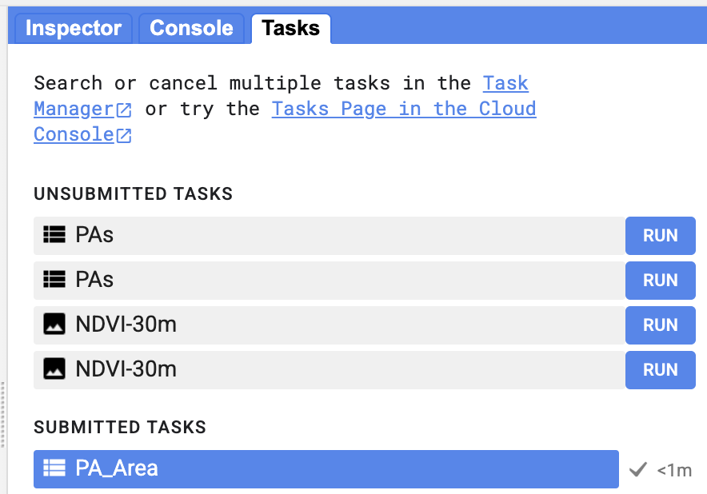

Figure 8. Exporting images and features.

You will see the csv file in your Google Drive (Fig. 9).

[figure not shown]

### 3.6 Conclusion

So far, we have seen some common functions to apply on images and features. There are an enormous amount of possible operations that can be applied to filter collections, calculate new bands, etc. As we progress with different types of analyses, you will get more familiarized with the different possible operations.

### 3.7 Assignment 2

In this second section, we have covered the basics of image, image collection, feature and feature collection operations in Google Earth Engine. The set of tools we have learned are the building blocks for more complex analyses. Thus, it is important to make sure you are familiar with these operations.

1. [Easy] Filter and display the Masai Mara boundary. You will use this feature for the subsequent activities.
2. [Easy] Select any image dataset from the GEE catalog that we did not use in the training. Export this image as a GeoTIFF to your Google Drive setting the extent for the Masai Mara.
3. [Moderate] Create a time series chart to compare mean NDVI and EVI from the MODIS satellite (Collection Name: MOD13Q1.006 Terra Vegetation Indices 16-Day Global 250m of MODIS) for the Masai Mara. Tip: [Here you can find examples of charts](https://developers.google.com/earth-engine/guides/charts_image_collection#uichartimageseries). You will need to use the `ui.Chart.image.series` function.
4. [Advanced] Load a road dataset for Africa using this feature collection `ee.FeatureCollection("projects/sat-io/open-datasets/GRIP4/Africa");` Create a distance to roads image for the entire Masai Mara.
5. [Advanced] Write a function to calculate a Modified Soil Adjusted Vegetation Index band (MSAVI). https://www.usgs.gov/landsat-missions/landsat-modified-soil-adjusted-vegetation-index. Map this function across a Landsat 8 collection to add an MSAVI band to each image Create a median pixel composite and add this layer to your map window.

Solutions code by clicking [here](https://code.earthengine.google.com/c550161bdb8fa961412d79d715462b32)

## 4 Exporting data and making a map in R

This third section is intended for you to practice what you have learned and then connect it to R, so we start to bring back things we have learned in the past.

### 4.1 Export an image from GEE

We will first start by creating an image in GEE and then exporting it to Google Drive.

Here, I present an example to map fires across the Mara region using the `ESA/CCI/FireCCI/5_1` product. This MODIS Fire_cci Burned Area product is a monthly global ~250m spatial resolution dataset containing information on burned area. The dataset includes, among other information, for each pixel the estimated day of the first detection of the fire. For a complete description of this dataset, see the information available on GEE.

#### 4.1.1 Define your area of interest

We can recall from the previous lesson how to use the World PA polygons to use the Mara and Great Mara Conservancies boundaries as our area of interest (AOI).

Note, that I have created a geometry that I then use to filter the entire PA feature collection.

```javascript
var PA = ee.FeatureCollection('WCMC/WDPA/current/polygons');
// Filter to the Masai Mara
var AOI = PA.filterBounds(geometry);
Map.centerObject(AOI, 8)
Map.addLayer(AOI, {}, 'Masai Mara')
```

#### 4.1.2 Load fire dataset

We now need to load the fire image collection and filter it to the time frame we want. For this example, we will work with the year 2020. We then need to select the `BunrDate` band. This represents the estimated day of the year of the first detection of the burn.

```javascript
// Visualize FireCCI51 for one year
var annualFire = ee.ImageCollection('ESA/CCI/FireCCI/5_1')
                  .filterDate('2020-01-01', '2020-12-31')
                  .select('BurnDate');
print(annualFire)
```

#### 4.1.3 Calculate area burnt per month

```javascript
var burnDateToArea = function(img){
  var firearea = img.gte(0).multiply(0.25) // 0.5 * 0.5 km
                    .rename('BurntArea');
  return img.addBands(firearea);
};

var annualBurntArea = annualFire
            .map(burnDateToArea);
```

Next, we are going to plot the annual burnt area across the year. For this, we use the `ui.Chart.image.series()` function in GEE. We use a reducer to sum all the burnt area across the region for each month. Note that the function to calculate pixel area is not handy to get an overall estimate of burnt area.

```javascript
// Plot annual burnt area time series aggregated over the region of interest (AOI)
print(ui.Chart.image.series(annualBurntArea.select('BurntArea'), AOI, ee.Reducer.sum(), 250) // 250m resolution
    .setOptions({
      title: 'Total annual burnt area for PA',
      hAxis:
            {title: 'Years', titleTextStyle: {italic: false, bold: true}},
      vAxis: {
            title: 'Burnt area (km2)',
            titleTextStyle: {italic: false, bold: true}
          },
      lineWidth: 1,
      pointSize: 3,
}));
```

You should get something like this chart:

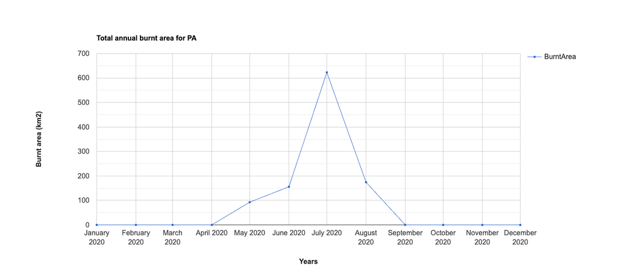

#### 4.1.4 Plot image

We can also visualize the image, with each color representing the last time at which the area was burnt. For this, we need to get the maximum value across the year image collection.

[figure not shown]

```javascript
// Use a circular palette to assign colors to date of first detection
var baVis = {
  min: 1,
  max: 366,
  palette: [
    'ff0000', 'fd4100', 'fb8200', 'f9c400', 'f2ff00', 'b6ff05',
    '7aff0a', '3eff0f', '02ff15', '00ff55', '00ff99', '00ffdd',
    '00ddff', '0098ff', '0052ff', '0210ff', '3a0dfb', '7209f6',
    'a905f1', 'e102ed', 'ff00cc', 'ff0089', 'ff0047', 'ff0004'
  ]
};
var maxBA = annualBurntArea.select("BurnDate").max().clip(AOI);
print(maxBA)

Map.addLayer(maxBA, baVis, 'Burned Area');
```

#### 4.1.5 Export data

Finally, we export the maxBA image and the PA polygons to Google Drive. We will use this products to make a map in R.

Something important is that we need to provide some number to the background pixels, which we want later to be NAs, so pixels with no data. We will do this by using the function `unmask()` and providing all background pixels a value of -9999. We will then transform those numbers to NAs in R.

```javascript
// Export raster image to Google Drive
Export.image.toDrive({
  image: maxBA.unmask(-9999),
  region: AOI,
  description: 'BurntAreas',
  folder: 'GIS',
  scale: 250,
  fileFormat: 'GeoTIFF',
  maxPixels: 1e10
});

// Export feature to Google Drive
Export.table.toDrive({
  collection: AOI,
  description: 'PAs',
  fileFormat: 'SHP',
  folder: 'GIS'
});
```

All the code to conduct this exercise can be retrieved from this [link](https://code.earthengine.google.com/be7804ad2f811e11c4f6658bf20bb634).

### 4.2 Creating a map in R

We will now move into R to learn how to make a cool map. For this, we will be learning the basics of making maps in R.

Before we start, and if you are not using an R project, do not forget to set your working directory

```r
setwd("...")
# don't forget to set the directory to your own data folder!!
```

#### 4.2.1 Making pretty maps with R

R offers the opportunity to create beautiful high quality maps for publication. This saves you from having to export all files to make the final maps in other software, such as ArcGIS or QGIS.

Making maps is like art. Good maps can help enormously with presenting your results to an audience. It takes skills and practice. When combining R powerful data processing with visualization packages, we can move beyond static maps. Here, we will learn the basics for making two type of maps:

1. Static maps
2. Interactive maps

We will use the ‘tmap’ package, which is a great new addition to R tools. Tmap is a powerful and flexible package with a concise syntax that is similar to ggplot2 users. It also has the unique capability to generate static and interactive maps using the same code via `tmap_mode()`.

```r
library(tmap)
library(spData)
```

Before we start using tmap, remember that you always have the help. Some functions in tmap have lots of arguments that can be edited. We will cover some basics here, hoping that you will explore more options on your own.

#### 4.2.2 Static maps - the basics

We will use generic data to demonstrate the basics, and then use some of the data from this chapter to create a publishable map.

Static maps are the most common and traditional outputs from geospatial analysis.

Tmap syntax involves a separation between the input data and the aesthetics for data visualization. Each input dataset can be displayed in many different ways, largely depending on the nature of the data (raster, points, polygons, etc.)

The dataset we are using here is the world object from the ‘spData’ package. It contains some variables from the World Bank.

In tmap the basic building block is `tm_shape()`, which creates a tmap-element that defines input data as vector or raster objects. We can then add one or more layer elements such as `tm_fill()`, `tm_borders()`, `tm_dots()`, `tm_raster()`, depending what you want to display.

Here a simple example:

```r
data(world)

# Add fill layer to shape
tm_shape(world) +
  tm_fill()
```

```
## [tip] Consider a suitable map projection, e.g. by adding `+ tm_crs("auto")`.
```

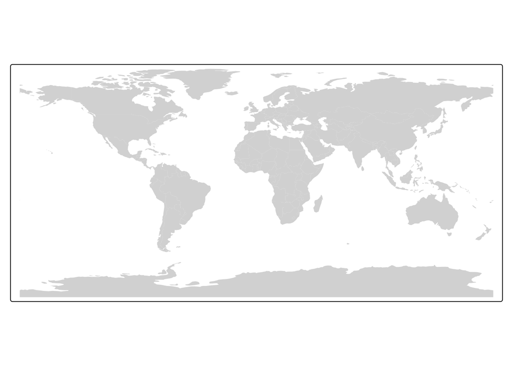

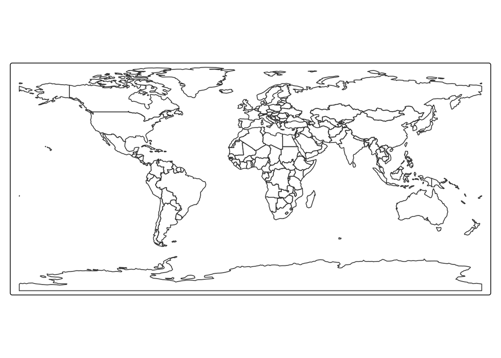

```r
# Add border layer to shape
tm_shape(world) +
  tm_borders()
```

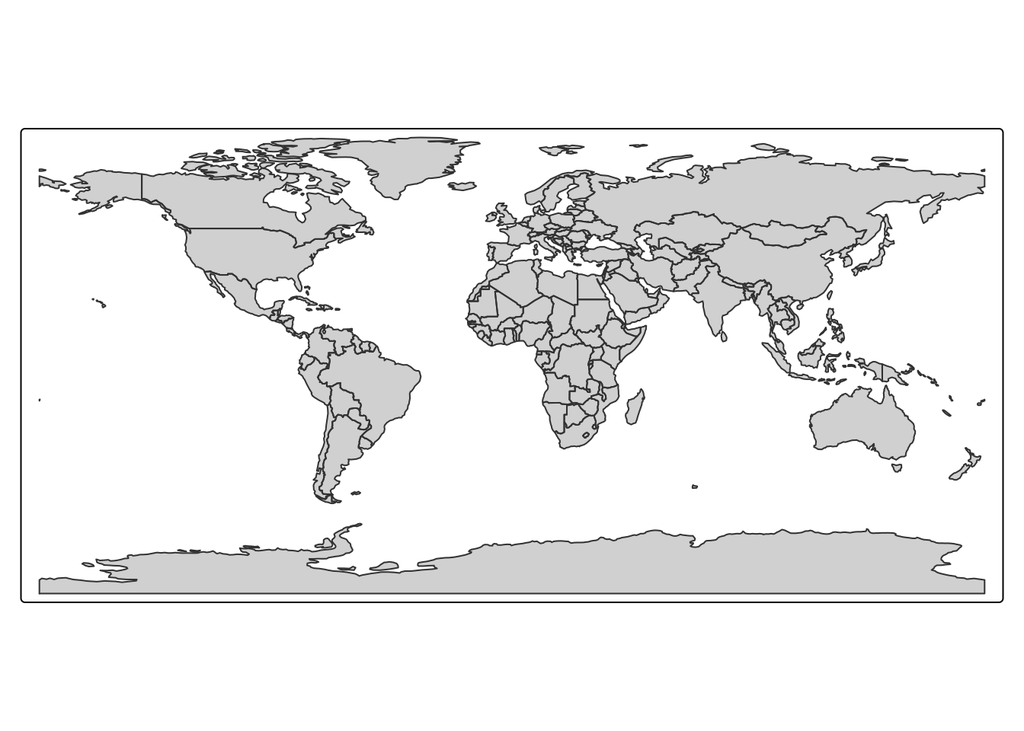

```r
# Add fill and border layers to shape
tm_shape(world) +
  tm_fill() +
  tm_borders()
```

Objects in tmap can be store with names, similar to ggplot, and then called or used as starting point to add more objects.

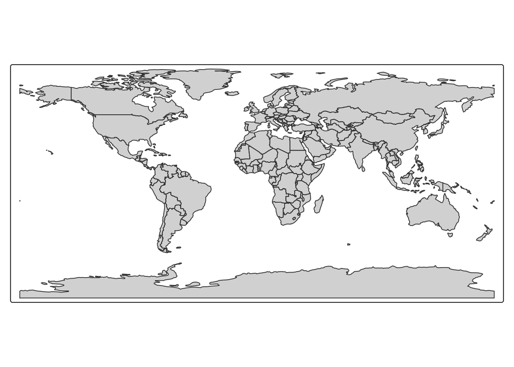

```r
map1 <- tm_shape(world) +
  tm_fill() +
  tm_borders()
map1
```

If we want to add more objects (e.g., another shapefile), we use `+ tm_shape(new_obj)`. When a new shape is added in this way, all subsequent aesthetic functions refer to it, until another new shape is added. This syntax allows the creation of maps with multiple shapes and layers.

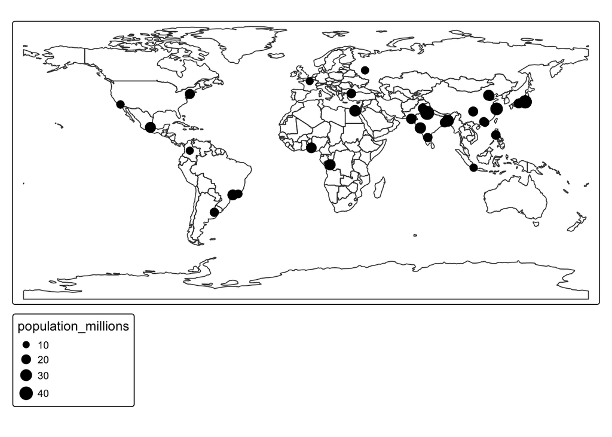

```r
tm_shape(world) +
    tm_borders() +
tm_shape(urban_agglomerations) +
    tm_dots(size = "population_millions")
```

In addition, you can change the aesthetics of the maps using either variable fields (data in your shapefile) or constant values. The most commonly used aesthetics for fill and border layers include color, transparency, line width and line type. In the new version of tmap, we set color for the area of polygons using the `fill` argument and the color of borders using the `col` argument. To add transparency, we use `fill_alpha` and `col_alpha`.

Here some examples on using constant numbers and colors. Note the use of `tmap_arrange` to plot multiple maps.

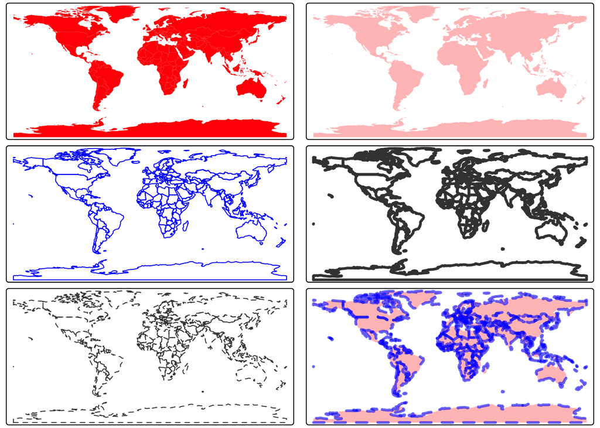

```r
ma1 = tm_shape(world) + tm_fill(fill = "red")
ma2 = tm_shape(world) + tm_fill(fill = "red", fill_alpha = 0.3)
ma3 = tm_shape(world) + tm_borders(col = "blue")
ma4 = tm_shape(world) + tm_borders(lwd = 3)
ma5 = tm_shape(world) + tm_borders(lty = 2)
ma6 = tm_shape(world) + tm_fill(fill = "red", fill_alpha = 0.3) +
  tm_borders(col = "blue", col_alpha = 0.6, lwd = 3, lty = 2)
tmap_arrange(ma1, ma2, ma3, ma4, ma5, ma6)
```

But we can also color the maps based on some variable of interest. You can use the default breaks for continuous variables or define your own. We use the `fill.scale` argument to set the color palette and the number of bins into which numeric variables are categorized. Here, we will use the `brewer.bu_gn` palette that gives different tones of blue.

You can use palettes from the R package cols4all. Run `cols4all::c4a_gui()` to explore them.

Lets plot population size by country:

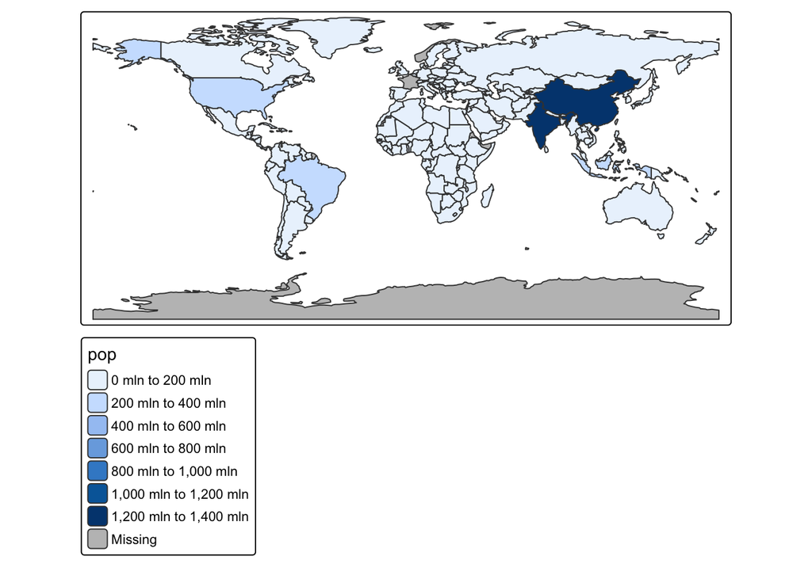

```r
tm_shape(world) + tm_polygons(fill = "pop") #default breaks
```